# Air Quality Forecast

Helen Chang

2019/4/16

### 1) Introduction

An air quality index is set to be indicate the level of pollution in the area. As the AQI increases, an increasingly large percentage of the population is likely to experience increasingly severe adverse health effects. Therefore, forcasting the air quality is helpful for the public awareness and also for the government to take action or control.

### 2) Data Summary

#### Attribute Information: The dataset has been reorganized with more comprehensive naming.

[Data source](https://archive.ics.uci.edu/ml/datasets/Air+Quality)

1. CO: [3] PT08.S1 (tin oxide) hourly averaged sensor response (nominally CO targeted)
2. CO_GT: [2] True hourly averaged concentration CO in mg/m<sup>3</sup> (reference analyzer)
3. NMHC: [6] PT08.S2 (titania) hourly averaged sensor response (nominally NMHC targeted)
4. NMHC_GT: [4] True hourly averaged overall Non Metanic HydroCarbons concentration in $\mu g/m^{3}$ (reference analyzer)
5. NO2: [10] PT08.S4 (tungsten oxide) hourly averaged sensor response (nominally NO<sub>2</sub> targeted)
6. NO2_GT: [9] True hourly averaged NO<sub>2</sub> concentration in $\mu g/m^{3}$ (reference analyzer)
7. NOx: [8] PT08.S3 (tungsten oxide) hourly averaged sensor response (nominally NO<sub>x</sub> targeted)
8. NOx_GT: [7] True hourly averaged NO<sub>x</sub> concentration in ppb (reference analyzer)
9. O3: [11] PT08.S5 (indium oxide) hourly averaged sensor response (nominally O<sub>3</sub> targeted)
10. C6H6_GT: [5] True hourly averaged Benzene concentration in $\mu g/m^{3}$ (reference analyzer)
11. T: [12] Temperature in °C
12. RH: [13] Relative Humidity (%)
13. AH: [14] Absolute Humidity
14. datetime: concatenate original data [0] Date (DD/MM/YYYY) and [1] Time (HH.MM.SS)

#### The table belows shows the summary statistics in each column.

- Take column CO as an example, the CO sensor response ranged from 647 to 2040, with the median (1063) slightly smaller than it’s mean (1099.83), which means it is right-skewed (as shown in the graph column). The dispersion also can be told as sd = 217.08 (standard deviation), IQR = 294 (interquantile range) and CV = 0.2 (coefficient of variation [[ref]](https://en.wikipedia.org/wiki/Coefficient_of_variation)).
- Also the datetime of this dataset starts from 2004-03-10 18:00:00 to 2005-04-04 14:00:00, which are 9357 hours (more than 389 days) in total.

| **No** | **Variable** | **Stats / Values** | **Freqs (% of Valid)** | **Graph** | **Valid** | **Missing** |
| --- | --- | --- | --- | --- | --- | --- |
| 1 | CO [integer] | mean (sd) : 1099.83 (217.08) min < med < max : 647 < 1063 < 2040 IQR (CV) : 294 (0.2) | 1041 distinct values |  | 8991 (96.09%) | 366 (3.91%) |
| 2 | CO_GT [numeric] | mean (sd) : 2.15 (1.45) min < med < max : 0.1 < 1.8 < 11.9 IQR (CV) : 1.8 (0.68) | 96 distinct values |  | 7674 (82.01%) | 1683 (17.99%) |
| 3 | NMHC [integer] | mean (sd) : 939.15 (266.83) min < med < max : 383 < 909 < 2214 IQR (CV) : 381.5 (0.28) | 1245 distinct values |  | 8991 (96.09%) | 366 (3.91%) |
| 4 | NMHC_GT [integer] | mean (sd) : 218.81 (204.46) min < med < max : 7 < 150 < 1189 IQR (CV) : 230 (0.93) | 429 distinct values |  | 914 (9.77%) | 8443 (90.23%) |
| 5 | NO2 [integer] | mean (sd) : 1456.26 (346.21) min < med < max : 551 < 1463 < 2775 IQR (CV) : 447 (0.24) | 1603 distinct values |  | 8991 (96.09%) | 366 (3.91%) |
| 6 | NO2_GT [numeric] | mean (sd) : 113.09 (48.37) min < med < max : 2 < 109 < 340 IQR (CV) : 64 (0.43) | 283 distinct values |  | 7715 (82.45%) | 1642 (17.55%) |
| 7 | NOx [integer] | mean (sd) : 835.49 (256.82) min < med < max : 322 < 806 < 2683 IQR (CV) : 311.5 (0.31) | 1221 distinct values |  | 8991 (96.09%) | 366 (3.91%) |
| 8 | NOx_GT [integer] | mean (sd) : 246.9 (212.98) min < med < max : 2 < 180 < 1479 IQR (CV) : 228 (0.86) | 925 distinct values |  | 7718 (82.48%) | 1639 (17.52%) |
| 9 | O3 [integer] | mean (sd) : 1022.91 (398.48) min < med < max : 221 < 963 < 2523 IQR (CV) : 542 (0.39) | 1743 distinct values |  | 8991 (96.09%) | 366 (3.91%) |
| 10 | C6H6_GT [numeric] | mean (sd) : 10.08 (7.45) min < med < max : 0.1 < 8.2 < 63.7 IQR (CV) : 9.6 (0.74) | 407 distinct values |  | 8991 (96.09%) | 366 (3.91%) |
| 11 | T [numeric] | mean (sd) : 18.32 (8.83) min < med < max : -1.9 < 17.8 < 44.6 IQR (CV) : 12.6 (0.48) | 436 distinct values |  | 8991 (96.09%) | 366 (3.91%) |
| 12 | RH [numeric] | mean (sd) : 49.23 (17.32) min < med < max : 9.2 < 49.6 < 88.7 IQR (CV) : 26.7 (0.35) | 753 distinct values |  | 8991 (96.09%) | 366 (3.91%) |
| 13 | AH [numeric] | mean (sd) : 1.03 (0.4) min < med < max : 0.18 < 1 < 2.23 IQR (CV) : 0.58 (0.39) | 6683 distinct values |  | 8991 (96.09%) | 366 (3.91%) |
| 14 | datetime [POSIXct, POSIXt] | min : 2004-03-10 18:00:00 med : 2004-09-21 16:00:00 max : 2005-04-04 14:00:00 range : 1y 0m 24d 20H 0M 0S | 9357 distinct val. |  | 9357 (100%) | 0 (0%) |

#### Missing Values

- NMHC_GT: Most of values are missing, with only 914 (9.77%) data points valid.
- CO_GT / NO2_GT / NOx_GT: these three variables are about 17.99% missing.
- The rest of 9 variables have 366 data points missing.

#### Pearson Correlation Coefficient

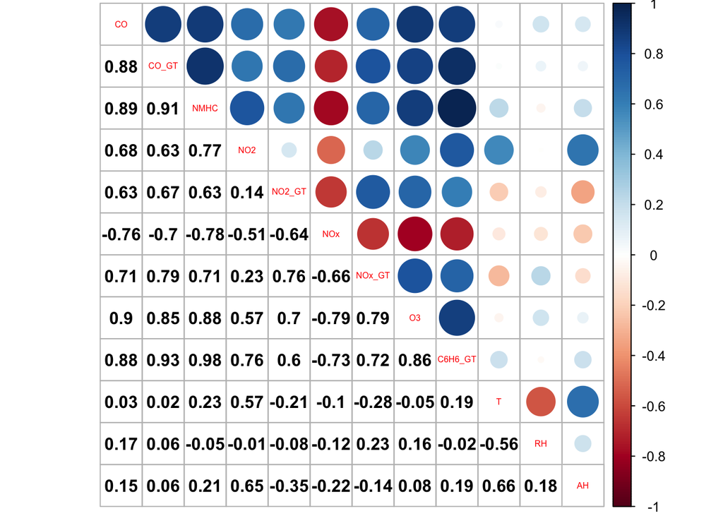

### 3) Fill the Missing Values

#### First try: simple linear regression

$CO\_GT=a_1 * CO + a_0$

- Since variable CO is from the sensor response and is hightly related to the reference analyzer values of CO_GT (cor=0.88), simple linear regression is promising.

```
##
## Call:
## lm(formula = CO_GT ~ CO, data = dt.co)
##
## Residuals:
##     Min      1Q  Median      3Q     Max
## -2.9862 -0.3917 -0.0342  0.3206  4.7067
##
## Coefficients:
##               Estimate Std. Error t value Pr(>|t|)
## (Intercept) -4.285e+00  4.133e-02  -103.7   <2e-16 ***
## CO           5.776e-03  3.651e-05   158.2   <2e-16 ***
## ---
## Signif. codes:  0 '***' 0.001 '**' 0.01 '*' 0.05 '.' 0.1 ' ' 1
##
## Residual standard error: 0.6842 on 7342 degrees of freedom
## Multiple R-squared:  0.7731, Adjusted R-squared:  0.7731
## F-statistic: 2.502e+04 on 1 and 7342 DF,  p-value: < 2.2e-16
```

- Above shows the adjusted R-squared = 0.7731, it’s a good start.
- But the scatter plot (figure below) between CO and CO_GT seems that it might need some transformation.

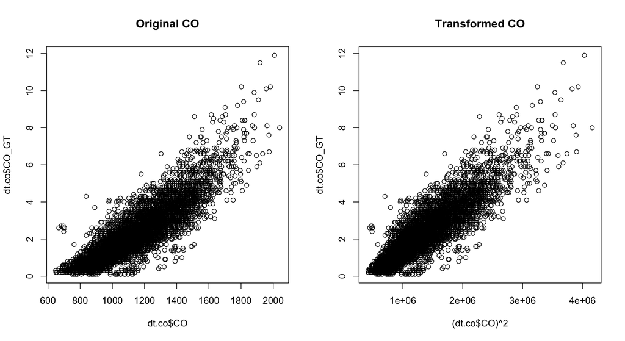

#### Second try: data transformation

$CO\_GT = a_1 * CO^2 + a_0$

```
##
## Call:
## lm(formula = CO_GT ~ CO_sq, data = dt.co)
##
## Residuals:
##     Min      1Q  Median      3Q     Max
## -2.9990 -0.3666 -0.0455  0.2950  4.0435
##
## Coefficients:
##               Estimate Std. Error t value Pr(>|t|)
## (Intercept) -9.829e-01  2.045e-02  -48.06   <2e-16 ***
## CO_sq        2.429e-06  1.477e-08  164.46   <2e-16 ***
## ---
## Signif. codes:  0 '***' 0.001 '**' 0.01 '*' 0.05 '.' 0.1 ' ' 1
##
## Residual standard error: 0.6638 on 7342 degrees of freedom
## Multiple R-squared:  0.7865, Adjusted R-squared:  0.7865
## F-statistic: 2.705e+04 on 1 and 7342 DF,  p-value: < 2.2e-16
```

- Adjusted R-squared went up to 0.7865.

#### Third try: adding more variables with relatively high correlation coefficents

$CO\_GT = a_2 * C6H6\_GT + a_1 * CO^2 + a_0$

```
##
## Call:
## lm(formula = CO_GT ~ CO_sq + C6H6_GT, data = dt.co)
##
## Residuals:
##     Min      1Q  Median      3Q     Max
## -6.5043 -0.2409 -0.0215  0.2087  3.3818
##
## Coefficients:
##               Estimate Std. Error t value Pr(>|t|)
## (Intercept) -2.286e-01  1.773e-02  -12.89   <2e-16 ***
## CO_sq        7.978e-07  2.318e-08   34.42   <2e-16 ***
## C6H6_GT      1.300e-01  1.634e-03   79.60   <2e-16 ***
## ---
## Signif. codes:  0 '***' 0.001 '**' 0.01 '*' 0.05 '.' 0.1 ' ' 1
##
## Residual standard error: 0.4864 on 7341 degrees of freedom
## Multiple R-squared:  0.8854, Adjusted R-squared:  0.8854
## F-statistic: 2.836e+04 on 2 and 7341 DF,  p-value: < 2.2e-16
```

- Adjusted R-squared improved to 0.8854.
- There’s no need to transform the variable C6H6_GT as shown in figure below:

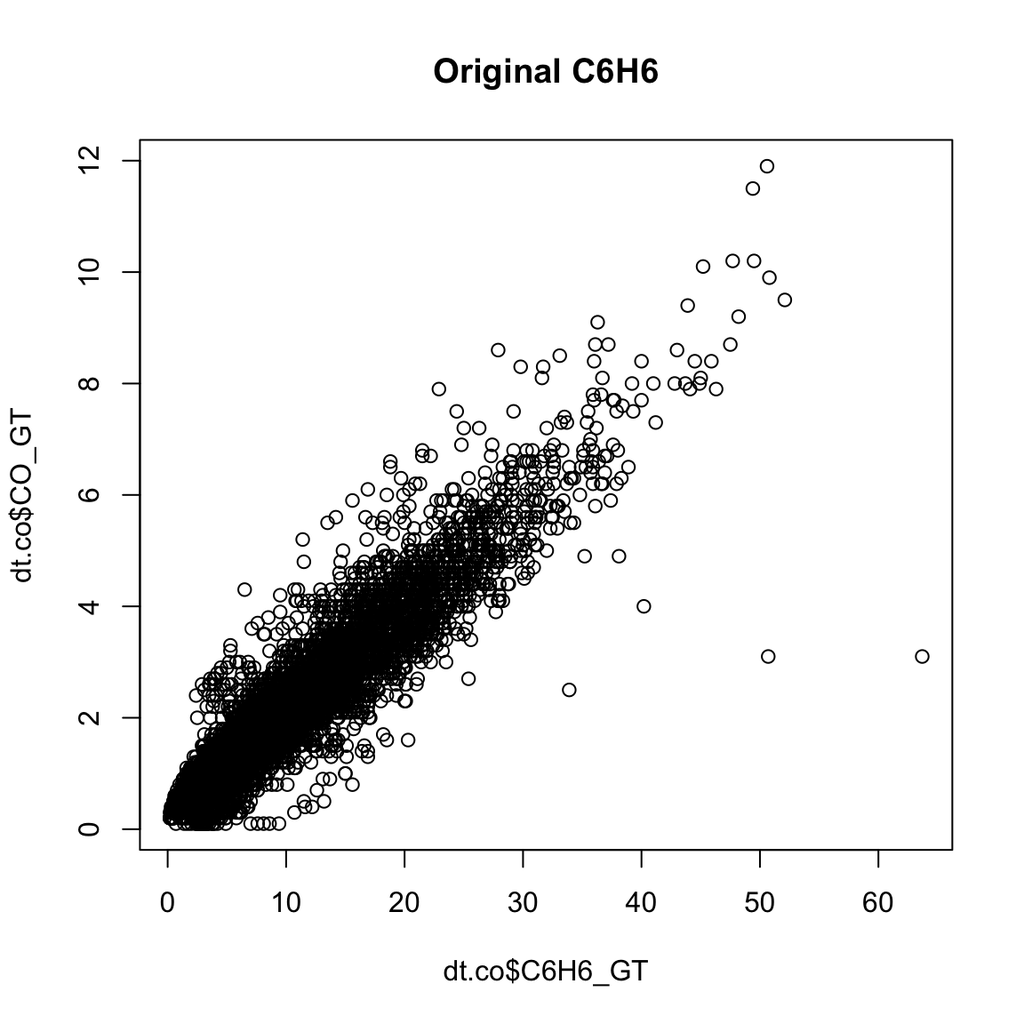

#### Finally: fill the predicted values into CO_GT variable.

- Still, there are 36 data points remain NA in variable CO_GT.
- Try handeling the rest of the missing values by simple average of nearest data point in +/- one hour, and +/- one day (24 hour).

```r
na.fill <- sapply(which(is.na(dt$CO_GT)), function (i) {
  dt$CO_GT[c(i-1, i+1, i-24, i+24)] %>% mean(., na.rm = T)
})
dt[is.na(dt$CO_GT), CO_GT:=na.fill]
```

- Some of the correlation between CO_GT and other chemical compunds slightly increased (+/-0.02 max), but not a very big influence.

```r
print(list(deviation=round(fitted.CO_GT.corr-original.CO_GT.corr, 3),
           fitted.CO_GT.corr=fitted.CO_GT.corr,
           original.CO_GT.corr=original.CO_GT.corr))
```

```
## $deviation
##      CO   CO_GT    NMHC     NO2  NO2_GT     NOx  NOx_GT      O3 C6H6_GT
##   0.004   0.000   0.002   0.004   0.007  -0.004   0.000   0.002   0.003
##       T      RH      AH
##   0.019  -0.020   0.005
##
## $fitted.CO_GT.corr
##          CO       CO_GT        NMHC         NO2      NO2_GT         NOx
##  0.88069094  1.00000000  0.91674084  0.63512734  0.68129610 -0.70491463
##      NOx_GT          O3     C6H6_GT           T          RH          AH
##  0.78648124  0.85569552  0.93314735  0.03718900  0.04456844  0.06469733
##
## $original.CO_GT.corr
##          CO       CO_GT        NMHC         NO2      NO2_GT         NOx
##  0.87701378  1.00000000  0.91431022  0.63083404  0.67383957 -0.70103781
##      NOx_GT          O3     C6H6_GT           T          RH          AH
##  0.78645556  0.85348004  0.93000844  0.01833425  0.06475315  0.05934617
```

- Same NA handling can be performed on NO2_GT and NOx_GT variables.

### 4) Air Quality Index

#### The [air quality index](https://en.wikipedia.org/wiki/Air_quality_index) is calculated regarding to the air pollutant concertrations and have different standards from different countries.

From the dataset, the concentration of CO and NO<sub>2</sub> were provided among the six categories mentioned on EPA’s website [[ref]](https://taqm.epa.gov.tw/taqm/tw/b0201.aspx), as shown in the following figure.

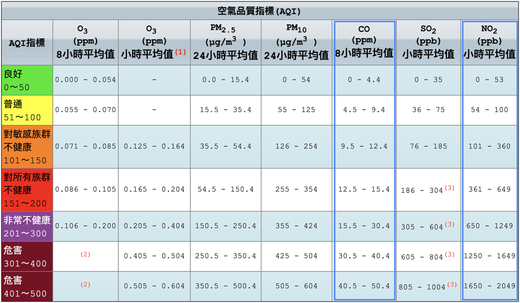

Fig. The Air Quality Index from EPA Taiwan

#### Calculation of the Air Quality Index (CO and NO<sub>2</sub>)

- Now try to calculate the air quality index from the original chemical concentrations of CO_GT. (Also applied to NO2_GT, but skipped here.)

```r
# Calculation example: original chemical concentrations (CO)
# [ref] http://www.aresok.org/npg/nioshdbs/calc.htm (25 degrees Celsius assumed)
# Smoothing: 8 hour moving average
co.smooth <- (dt$CO_GT[!is.na(dt$CO_GT)] * 24.45 / 28) %>%
  movavg(., 8, "s") %>%
  round(., 1)
# Set the air quality intervals
air.quality.lvls <- c(0, 51, 101, 151, 201, 301, 401)
# Set the CO concentration intervals
breaks <- c(0, 4.5, 9.5, 12.5, 15.5, 30.5, 40.5, 50.4)
# Identify which interval
lvls <- cut(co.smooth, breaks) %>% as.integer()
# Calculate the air quality index
co.calculate <- ((air.quality.lvls[lvls+1] - air.quality.lvls[lvls]) * (co.smooth-breaks[lvls])) / (breaks[lvls+1] - breaks[lvls]) + air.quality.lvls[lvls]
# Round up air quality index of CO
dt[!is.na(CO_GT), `:=` (CO.index=round(co.calculate, 1),
                        CO.level=lvls)]
```

Compare the level of air quality between CO and NO<sub>2</sub>:  
* Level 1: AQI = 0 ~ 50 (Good)  
* Level 2: AQI = 51 ~ 100 (Normal)  
* Level 3: AQI = 101 ~ 150 (Harmful to sensitive people)  
* Level 4: AQI = 151 ~ 200 (Unhealthy to everyone)  
* Level 5: AQI = 201 ~ 300 (Very Unhealthy)  
* Level 6/7: AQI = 301 ~ 500 (Dangerous)  
As we can see the level of NO<sub>2</sub> is relatively higher than CO, where NO<sub>2</sub> has nearly 40% of time reach level 3 (harmful to sensitive people).

| **CO.level** | NO2.level 1 | NO2.level 2 | NO2.level 3 | NO2.level <NA> | Total |
| --- | --- | --- | --- | --- | --- |
| **1** | 846 (9.04%) | 4722 (50.46%) | 3615 (38.63%) | 43 (0.46%) | 9226 (98.60%) |
| **2** | 0 (0.00%) | 4 (0.04%) | 126 (1.35%) | 1 (0.01%) | 131 (1.40%) |
| **Total** | 846 (9.04%) | 4726 (50.51%) | 3741 (39.98%) | 44 (0.47%) | 9357 (100.00%) |

#### Benzene Mesurement for Air Quality (C6H6_GT)

- Benzene is not listed in the table of EPA, however, it is hazardous to human body when it exceeds a certain level (17 $\mu g/m^{3}$ [[ref]](https://www.iaq.gov.hk/media/67695/annex-summary-of-old-and-new-iaqos_chi_v2.pdf)).
- Similar to the level of AQI, it is set to level 1 as safe (C6H6_GT < 17), and level 3 as hazardous (C6H6_GT >= 17), since level 1 and 2 defined in AQI are health condition.

```
## C6H6.level
## Hazardous      Safe
##      1100      7891
```

| **C6H6.level** | NO2.level 1 | NO2.level 2 | NO2.level 3 | NO2.level <NA> | Total |
| --- | --- | --- | --- | --- | --- |
| **1** | 834 (8.91%) | 4483 (47.91%) | 2574 (27.51%) | 0 (0.00%) | 7891 (84.33%) |
| **3** | 0 (0.00%) | 132 (1.41%) | 968 (10.35%) | 0 (0.00%) | 1100 (11.76%) |
| **<NA>** | 12 (0.13%) | 111 (1.19%) | 199 (2.13%) | 44 (0.47%) | 366 (3.91%) |
| **Total** | 846 (9.04%) | 4726 (50.51%) | 3741 (39.98%) | 44 (0.47%) | 9357 (100.00%) |

- It is noticed that 44 data points of NO<sub>2</sub> are missing and need to be filled later.

#### O<sub>3</sub> Estimation

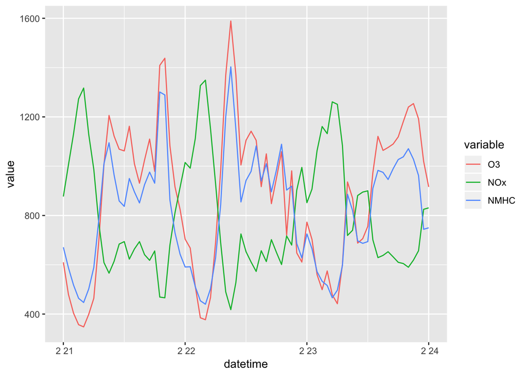

```
##
##    1    2    3    4    5 <NA>
## 1577  777  789  900 2125 3189
```

#### Integrated Air Quality Index

```
##                  datetime CO.level NO2.level C6H6.level AQI.level
##    1: 2004-03-10 18:00:00        1         2          1         2
##    2: 2004-03-10 19:00:00        1         2          1         2
##    3: 2004-03-10 20:00:00        1         2          1         2
##    4: 2004-03-10 21:00:00        1         2          1         2
##    5: 2004-03-10 22:00:00        1         2          1         2
##   ---
## 9353: 2005-04-04 10:00:00        1         3          1         3
## 9354: 2005-04-04 11:00:00        1         3          1         3
## 9355: 2005-04-04 12:00:00        1         3          1         3
## 9356: 2005-04-04 13:00:00        1         3          1         3
## 9357: 2005-04-04 14:00:00        1         3          1         3
```

### 5) Air Quality Prediction

- According to the previous result, it seems that the integrated AIQ for the next 5 days (120 hours) is up to 3 levels and could be trained by RNN. Also the temperature and humidity could be leveraged to since the relationship between air quality and the weather condition can be further discussed.
- But before preparing and exploring more features and try RNN method (will not be included in this report), **single variable of time series forcasting can be preformed as base line**.

#### First Try on predition to Air Quality Index of CO (Single-Variable)

- To predict the next 5 days (120 hours) IAQI of CO by ARIMA model.
- First check the stationarity the IAQI_CO:

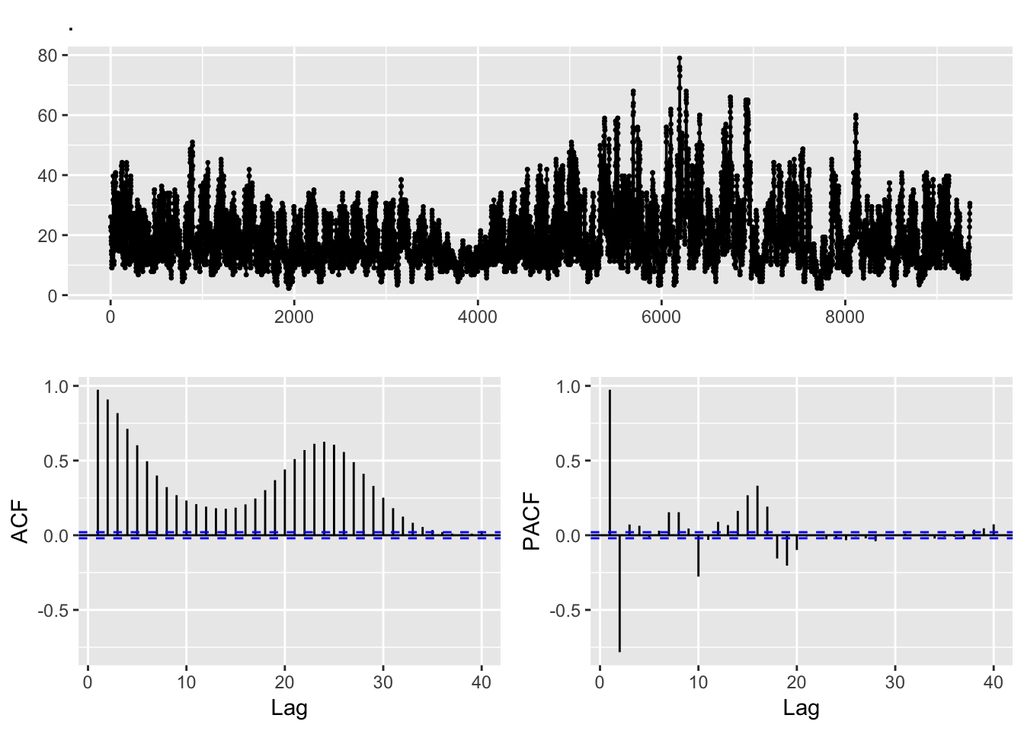

- The IAQI_CO is not stationary and should perform first-level difference.

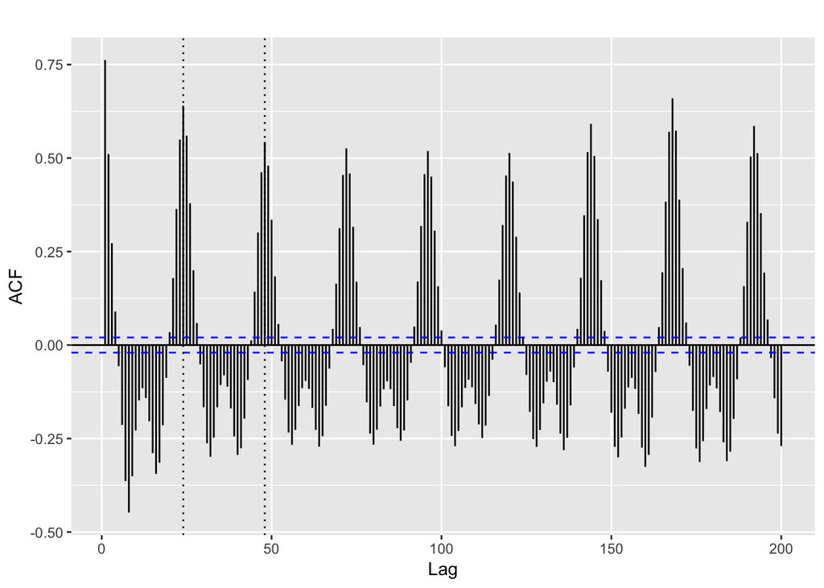

```r
t.data <- dt$CO.index %>% diff()
ggAcf(t.data,main="", lag.max=200) + geom_vline(xintercept = c(24, 48), linetype="dotted")
```

- After first-difference it looks like 24 lag periodically.
- Further specified lag 24 in diff() yet another period around lag 168 as shown below:

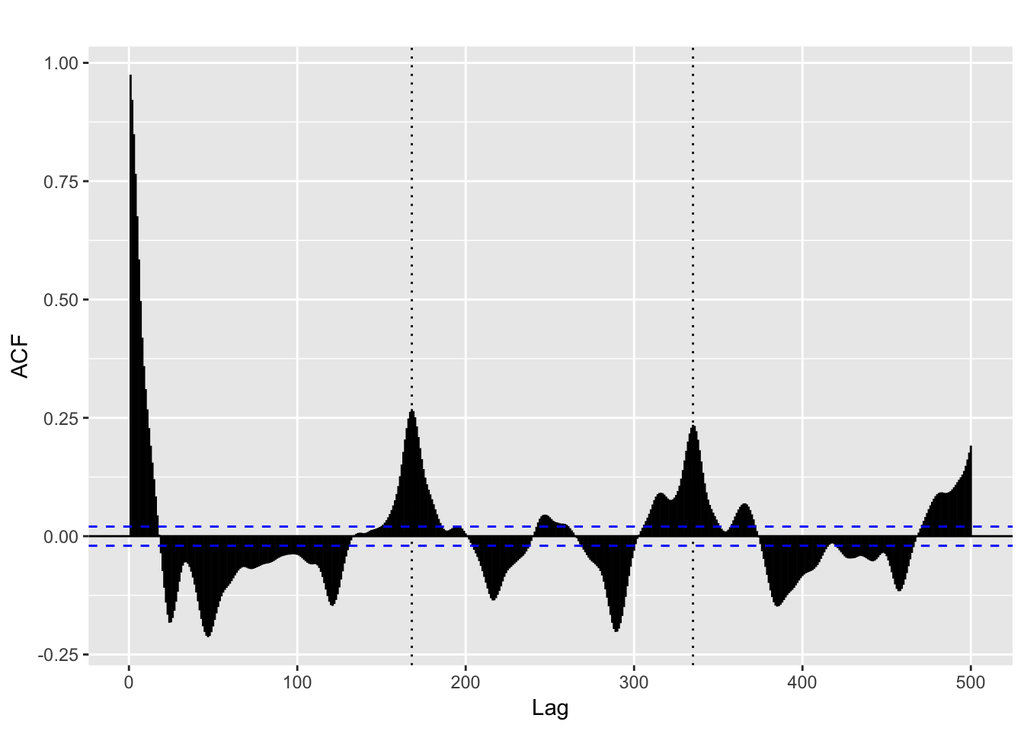

```r
t.data <- dt$CO.index %>% diff(24)
ggAcf(t.data,main="", lag.max=500) + geom_vline(xintercept = c(168, 335), linetype="dotted")
```

- Therefore the seasonal period = 168 is determined. Others parameters are selected by the lowest AICc, as ARIMA(p,d,q)(P,D,Q)<sub>period</sub> = ARIMA(3,1,2)(0,1,0)<sub>168</sub>.
- 8736 hours of data points were selected for training, and the next 120 hours of data points were kept for validation set.
- As we can see in the fitted result, the periodic patterns were significantly reduced, compare to the previous Acf plot. This should be the improvement factor of better ARIMA model.

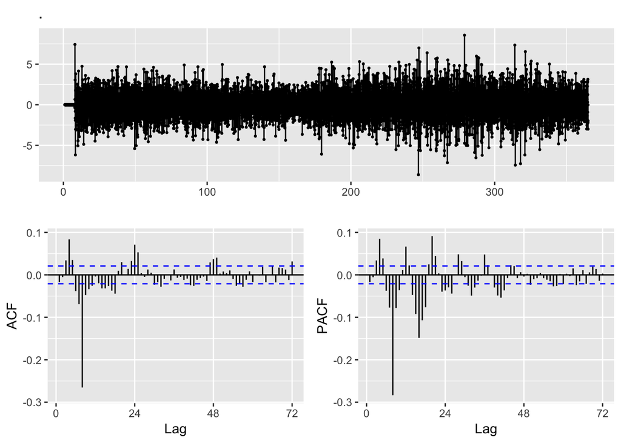

- Below shows the fitted plot:
- The MAE and RMSE of the result is around 8 and 9.63 accordingly.

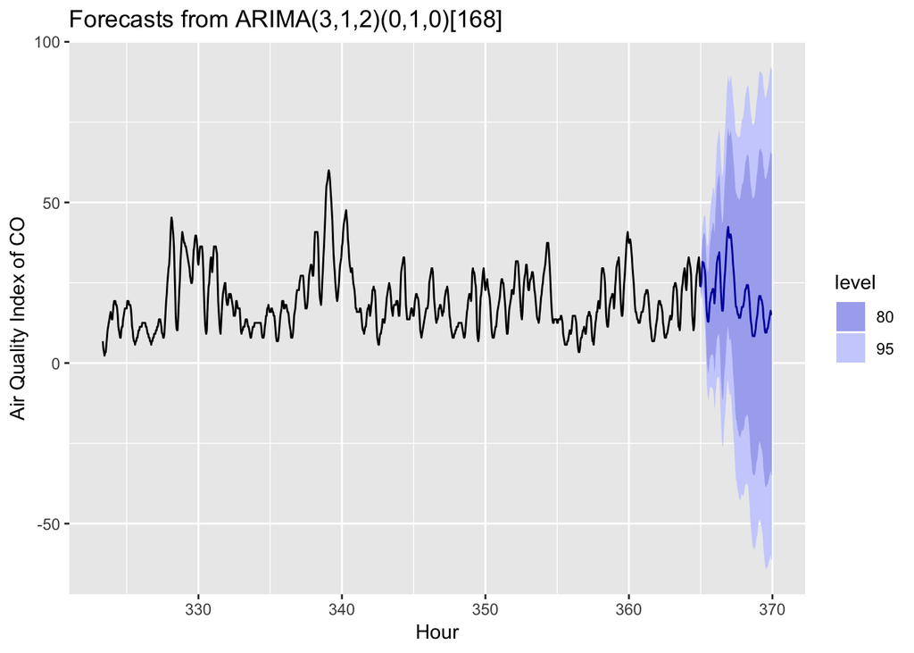

```r
pred %>% autoplot(include = 1000) + ylab("Air Quality Index of CO") + xlab("Hour")
```

* The IAQI of NO<sub>2</sub> and C<sub>6</sub>H<sub>6</sub> (Benzene) can be predicted by ARIMA in a similar way.